# An introduction to linear mixed-effects models

11/19/14

## Background

## An example: Sleep study data

### Description

The average reaction time per day for subjects in a sleep deprivation study. On day 0 the subjects had their normal amount of sleep. Starting that night they were restricted to 3 hours of sleep per night. The observations represent the average reaction time on a series of tests given each day to each subject.

### Format

A data frame with 180 observations on the following 3 variables:  
`Reaction`: Average reaction time (ms)  
`Days`: Number of days of sleep deprivation  
`Subject`: Subject number on which the observation was made.

## How would you analyze this data?

- Plotting doesn't count as analysis!
- Assume you can't use a mixed-effects model or repeated measures ANOVA.
- Common approach: average across subjects/days

## Summary of data

```r
head(sleepstudy)
```

```
##   Reaction Days Subject
## 1 249.5600    0     308
## 2 258.7047    1     308
## 3 250.8006    2     308
## 4 321.4398    3     308
## 5 356.8519    4     308
## 6 414.6901    5     308
```

```r
summary(sleepstudy)
```

```
##     Reaction          Days        Subject
##  Min.   :194.3   Min.   :0.0   308    : 10
##  1st Qu.:255.4   1st Qu.:2.0   309    : 10
##  Median :288.7   Median :4.5   310    : 10
##  Mean   :298.5   Mean   :4.5   330    : 10
##  3rd Qu.:336.8   3rd Qu.:7.0   331    : 10
##  Max.   :466.4   Max.   :9.0   332    : 10
##                                (Other):120
```

## All data

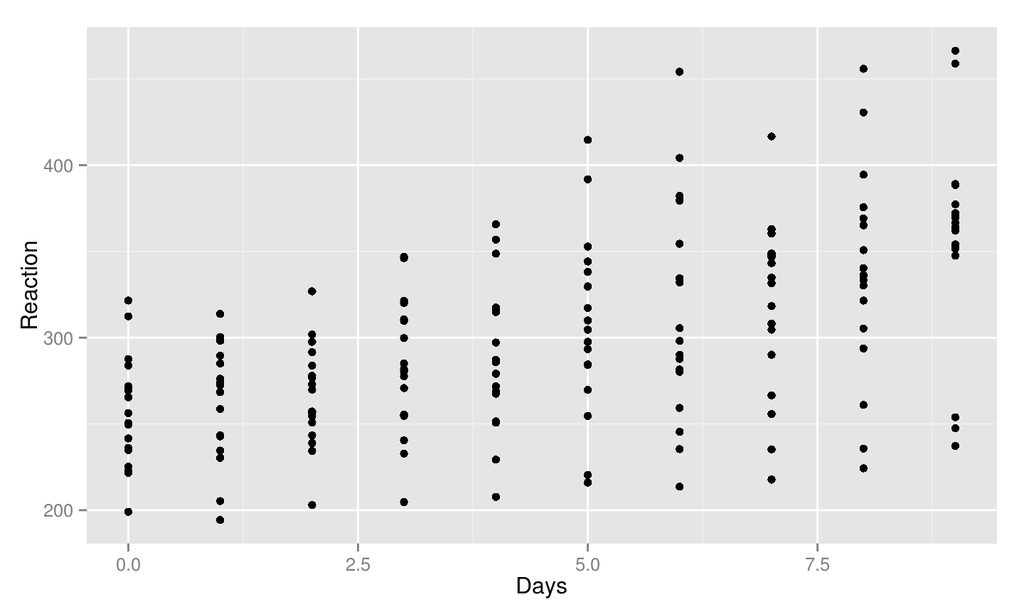

## Means across days

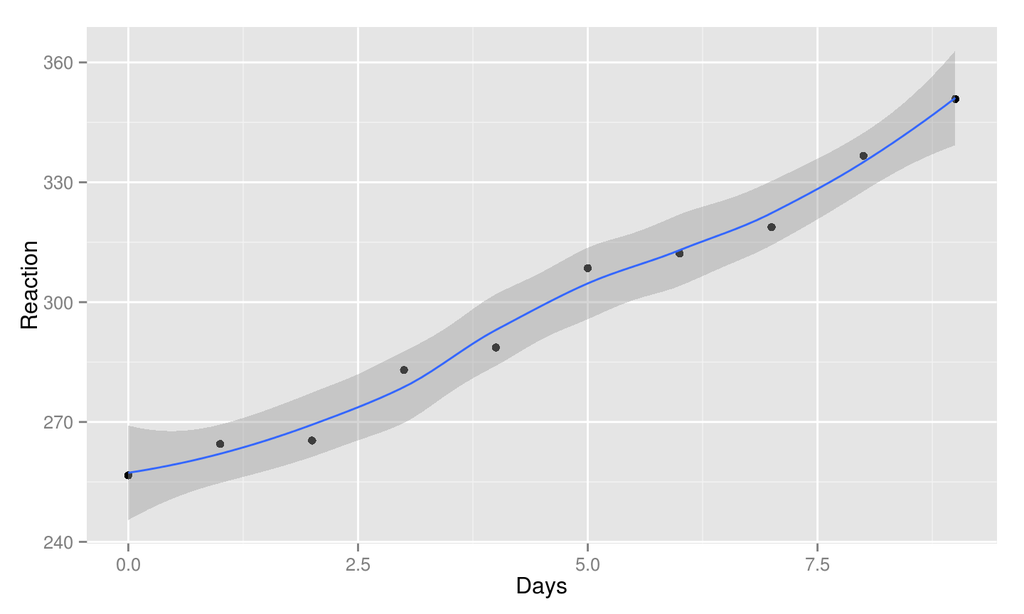

## Per-subject effect of days

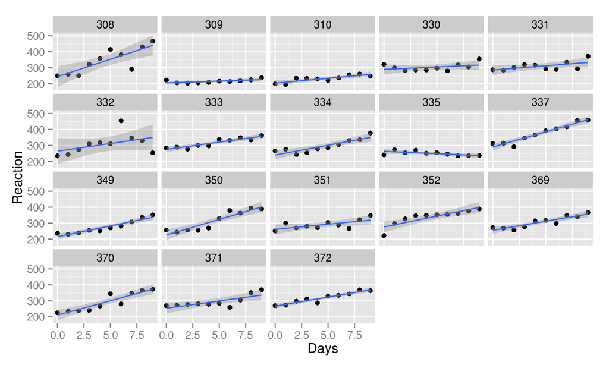

What if 308 and 337 are the only ones driving the effect? How do we account for the different effect size across participants?

## Defining mixed-effects models

## What do mixed-effects models do?

- Allow us to understand the observed variance as a combination of fixed and random effects
- Typically:
  - Fixed effect: "predictable" source of variance, if categorical it is possible to exhaust the space of values
  - Random effect: "random" source of variance, can be thought of as a subdivision of the error term
- Random effects are grouped by a categorical predictor but can include effects of continuous predictors within each level of the group

## When should you use mixed-effects models?

Lots of cases make sense, but here is the common case:

- You have repeated measures
- You have an unbalanced design, either intentionally (corpus or other uncontrolled study) or less so (limitation of experimental design) so repeated measures ANOVA should not be applied

## Fixed and random effects

- "One modeler's random effect is another modeler's fixed effect" (Kevin Wright)
- `sleepstudy` data set from `lme4`
  - Days
  - Subject
- In general, if you plan for testing for significance of a predictor, it will be a fixed effect
- Testing for significance of random effects is primarily useful in choosing among potential random effects structures

## Formula specification in `lme4`

- Looks very similar to standard linear regression
- First, consider a simple fixed-effects model:  
  `Reaction ~ 1 + Days`
- Think of `|` (AKA pipe, bar) as the grouping operator
- `(1 | x)` means "an intercept for each level of x"
- `(1 + a | x)` means "an intercept for each level of x and a slope for 'a' for each level of x"
- Intercepts are implicit so `(a | x) == (1 + a | x)`

## Random effects structures

- Per-subject random intercept: subjects vary in their average speed
- Per-subject random slope for days: subjects vary in how the number of days affects their reaction time

## Formula specification example

```r
summary(lm(Reaction ~ 1 + Days, sleepstudy))
```

```
##
## Call:
## lm(formula = Reaction ~ 1 + Days, data = sleepstudy)
##
## Residuals:
##      Min       1Q   Median       3Q      Max
## -110.848  -27.483    1.546   26.142  139.953
##
## Coefficients:
##             Estimate Std. Error t value Pr(>|t|)
## (Intercept)  251.405      6.610  38.033  < 2e-16 ***
## Days          10.467      1.238   8.454 9.89e-15 ***
## ---
## Signif. codes:  0 '***' 0.001 '**' 0.01 '*' 0.05 '.' 0.1 ' ' 1
##
## Residual standard error: 47.71 on 178 degrees of freedom
## Multiple R-squared:  0.2865, Adjusted R-squared:  0.2825
## F-statistic: 71.46 on 1 and 178 DF,  p-value: 9.894e-15
```

## Adding a random intercept

```r
summary(lmer(Reaction ~ 1 + Days + (1 | Subject), sleepstudy), correlation = FALSE)
```

```
## Linear mixed model fit by REML ['lmerMod']
## Formula: Reaction ~ 1 + Days + (1 | Subject)
##    Data: sleepstudy
##
## REML criterion at convergence: 1786.5
##
## Scaled residuals:
##     Min      1Q  Median      3Q     Max
## -3.2257 -0.5529  0.0109  0.5188  4.2506
##
## Random effects:
##  Groups   Name        Variance Std.Dev.
##  Subject  (Intercept) 1378.2   37.12
##  Residual              960.5   30.99
## Number of obs: 180, groups:  Subject, 18
##
## Fixed effects:
##             Estimate Std. Error t value
## (Intercept) 251.4051     9.7467   25.79
## Days         10.4673     0.8042   13.02
##
## Correlation of Fixed Effects:
##      (Intr)
## Days -0.371
```

## Adding a random slope

```r
summary(lmer(Reaction ~ 1 + Days + (Days | Subject), sleepstudy), correlation = FALSE)
```

```
## Linear mixed model fit by REML ['lmerMod']
## Formula: Reaction ~ 1 + Days + (Days | Subject)
##    Data: sleepstudy
##
## REML criterion at convergence: 1743.6
##
## Scaled residuals:
##     Min      1Q  Median      3Q     Max
## -3.9536 -0.4634  0.0231  0.4634  5.1793
##
## Random effects:
##  Groups   Name        Variance Std.Dev. Corr
##  Subject  (Intercept) 612.09   24.740
##           Days         35.07    5.922   0.07
##  Residual             654.94   25.592
## Number of obs: 180, groups:  Subject, 18
##
## Fixed effects:
##             Estimate Std. Error t value
## (Intercept)  251.405      6.825   36.84
## Days          10.467      1.546    6.77
##
## Correlation of Fixed Effects:
##      (Intr)
## Days -0.138
```

## Some rules of thumb

- To be a random grouping factor, something should have 5 or more levels
  - Why? Difficult to estimate variance reasonably with fewer levels
  - Example: How would you model suffix effects in a corpus where number of suffixes in the data is 3? How about 30?

## Examining fits

## Interpreting results

- Coefficients and standard errors are just like a fixed-effects model
- Rule of thumb for t-values: with infinite data, \(t = \pm 1.96 \rightarrow p = 0.05\)
- The best way to test for significance is to do an explicit model comparison
- For testing significance, the Chi-square log likelihood ratio test is your best bet
  - This applies as well for `glmer` fits, even though they print p-values in the summary

## Maximum likelihood

- When planning to compare models, pass the argument `REML = FALSE` to ensure the model is fit using a maximum likelihood criterion
- Maximum likelihood fit = the best combination of parameters *that could be found* for explaining the data, without imposing any prior on what the parameters should look like

## Significance testing

Test the significance of number of days:

```r
fm1 <- lmer(Reaction ~ 1 + (Days | Subject), sleepstudy, REML = FALSE)
fm2 <- lmer(Reaction ~ 1 + Days + (Days | Subject), sleepstudy, REML = FALSE)
anova(fm1, fm2)
```

```
## Data: sleepstudy
## Models:
## fm1: Reaction ~ 1 + (Days | Subject)
## fm2: Reaction ~ 1 + Days + (Days | Subject)
##     Df    AIC    BIC  logLik deviance  Chisq Chi Df Pr(>Chisq)
## fm1  5 1785.5 1801.4 -887.74   1775.5
## fm2  6 1763.9 1783.1 -875.97   1751.9 23.537      1  1.226e-06 ***
## ---
## Signif. codes:  0 '***' 0.001 '**' 0.01 '*' 0.05 '.' 0.1 ' ' 1
```

## Significance testing

For convenience, you can test all fixed effects by using `drop1`:

```r
drop1(fm2, test = "Chisq")
```

```
## Single term deletions
##
## Model:
## Reaction ~ 1 + Days + (Days | Subject)
##        Df    AIC    LRT   Pr(Chi)
## <none>    1763.9
## Days    1 1785.5 23.537 1.226e-06 ***
## ---
## Signif. codes:  0 '***' 0.001 '**' 0.01 '*' 0.05 '.' 0.1 ' ' 1
```

## Verifying that the random slopes are meaningful

```r
fm3 <- lmer(Reaction ~ 1 + Days + (1 | Subject), sleepstudy, REML = FALSE)
anova(fm2, fm3)
```

```
## Data: sleepstudy
## Models:
## fm3: Reaction ~ 1 + Days + (1 | Subject)
## fm2: Reaction ~ 1 + Days + (Days | Subject)
##     Df    AIC    BIC  logLik deviance  Chisq Chi Df Pr(>Chisq)
## fm3  4 1802.1 1814.8 -897.04   1794.1
## fm2  6 1763.9 1783.1 -875.97   1751.9 42.139      2  7.072e-10 ***
## ---
## Signif. codes:  0 '***' 0.001 '**' 0.01 '*' 0.05 '.' 0.1 ' ' 1
```

This is primarily for diagnosing model structure problems; it's unusual to report significance for a random effect term.

## Convergence issues

- Fitting a model of this type relies on optimization
- There is no guarantee that your model is the "best fit" or that a unique best fit even exists
- Things that affect convergence success and speed:
  - Centering *and standardizing* predictors, especially if they will be used as a random slope
  - If you're technically inclined, see `?nloptwrap` and used the `nlopt` implementation of BOBYQA
- What do you do if your model won't converge?
  - Look for high level of missingness in your data
  - Plot effects by your grouping factor to see if something stands out
  - If all else fails, try a simpler model

## The great random slope debate

- Barr et al. (2013) have argued for a "keep it maximal" strategy: essentially, put all the fixed effects you can into random slopes as well
- This is a good idea, but a lot of people make mistakes blindly following this:
  - Make sure each fixed effect actually varies by the grouping factor. If you are exploring gender effects and participants remain the same gender during the experiment, `(gender | Subject)` is not meaningful.
  - Multiple random slopes per grouping factor are difficult to estimate. For example, if your fixed effects are `A * B + C`, it is asking a lot from the model to estimate those terms per-subject.
- Always check for correlations of \(\pm 1\) among your random effects
- Douglas Bates (one of the creators of `lme4`) has discussed some of the issues in following a "keep it maximal" maxim, namely the fact that it [often leads to singular models](https://stat.ethz.ch/pipermail/r-sig-mixed-models/2014q4/022729.html)

## Further reading

- Winter, B. (2013). Linear models and linear mixed effects models in R with linguistic applications. arXiv:1308.5499. (http://arxiv.org/pdf/1308.5499.pdf)
- Useful posts by lme4 developers Douglas Bates and Ben Bolker
  - On p-values: [lmer, p-values and all that](https://stat.ethz.ch/pipermail/r-help/2006-May/094765.html)
  - More on the difficulty of computing denominator degrees of freedom: [residual df in lmer and simulation results](https://stat.ethz.ch/pipermail/r-help/2006-July/110133.html)
  - The conservativity of testing for random effect significance: [testing for significance in random-effect factors using lmer](https://stat.ethz.ch/pipermail/r-help/2005-July/075346.html)
  - Interpreting log-likelihood ratio tests: [Interpretation of lmer output in R](https://stat.ethz.ch/pipermail/r-sig-mixed-models/2011q1/015608.html)
  - When to drop non-significant or poorly estimated model terms: [lmer and p-values](https://stat.ethz.ch/pipermail/r-sig-mixed-models/2011q1/015958.html)

## Thanks!

- Questions?